# Project Assignment

Ahsan Ahmad

April 27, 2024

# 1 Libraries

```r
library(tidyverse)
```

```r
library(ggplot2)
library(psych)
library(caret)
library(rminer)
library(rmarkdown)
library(matrixStats)
library(knitr)
library(rpart)
library(RWeka)
library(kernlab)
library(arules)
library(arulesViz)
library(C50)
library(scatterplot3d)
library(e1071)
library(tictoc)
tic()
library(kernlab)
library(arules)
library(arulesViz)
library(partykit)
library(tibble)
```

# 2 Exploratory Data Analysis (EDA)

## 2.1 Set up, Data import, and Preparation

```r
# Setting up working directory and importing data from a csv file

cloud_wd <- getwd()
setwd(cloud_wd)

census <- read.csv(file = "census.csv", stringsAsFactors = TRUE)

# Looking at the structure and summary of the data and transforming chr variables into factors by putting stringsAsFactors = TRUE above after looking at the structure and summary of dataset

str(census)
```

```
## 'data.frame':    32561 obs. of  15 variables:
##  $ age           : int  39 50 38 53 28 37 49 52 31 42 ...
##  $ workclass     : Factor w/ 9 levels " ?"," Federal-gov",..: 8 7 5 5 5 5 5 7 5 5 ...
##  $ fnlwgt        : int  77516 83311 215646 234721 338409 284582 160187 209642 45781 159449 ...
##  $ education     : Factor w/ 16 levels " 10th"," 11th",..: 10 10 12 2 10 13 7 12 13 10 ...
##  $ education.num : int  13 13 9 7 13 14 5 9 14 13 ...
##  $ marital.status: Factor w/ 7 levels " Divorced"," Married-AF-spouse",..: 5 3 1 3 3 3 4 3 5 3 ...
##  $ occupation    : Factor w/ 15 levels " ?"," Adm-clerical",..: 2 5 7 7 11 5 9 5 11 5 ...
##  $ relationship  : Factor w/ 6 levels " Husband"," Not-in-family",..: 2 1 2 1 6 6 2 1 2 1 ...
##  $ race          : Factor w/ 5 levels " Amer-Indian-Eskimo",..: 5 5 5 3 3 5 3 5 5 5 ...
##  $ sex           : Factor w/ 2 levels " Female"," Male": 2 2 2 2 1 1 1 2 1 2 ...
##  $ capital.gain  : int  2174 0 0 0 0 0 0 0 14084 5178 ...
##  $ capital.loss  : int  0 0 0 0 0 0 0 0 0 0 ...
##  $ hours.per.week: int  40 13 40 40 40 40 16 45 50 40 ...
##  $ native.country: Factor w/ 42 levels " ?"," Cambodia",..: 40 40 40 40 6 40 24 40 40 40 ...
##  $ y             : Factor w/ 2 levels " <=50K"," >50K": 1 1 1 1 1 1 1 2 2 2 ...
```

```r
summary(census)
```

```
##       age                    workclass         fnlwgt
##  Min.   :17.00    Private         :22696   Min.   :  12285
##  1st Qu.:28.00    Self-emp-not-inc: 2541   1st Qu.: 117827
##  Median :37.00    Local-gov       : 2093   Median : 178356
##  Mean   :38.58    ?               : 1836   Mean   : 189778
##  3rd Qu.:48.00    State-gov       : 1298   3rd Qu.: 237051
##  Max.   :90.00    Self-emp-inc    : 1116   Max.   :1484705
##                  (Other)          :  981
##          education     education.num                  marital.status
##   HS-grad     :10501   Min.   : 1.00    Divorced             : 4443
##   Some-college: 7291   1st Qu.: 9.00    Married-AF-spouse    :   23
##   Bachelors   : 5355   Median :10.00    Married-civ-spouse   :14976
##   Masters     : 1723   Mean   :10.08    Married-spouse-absent:  418
##   Assoc-voc   : 1382   3rd Qu.:12.00    Never-married        :10683
##   11th        : 1175   Max.   :16.00    Separated            : 1025
##  (Other)      : 5134                    Widowed              :  993
##             occupation            relationship                    race
##   Prof-specialty :4140    Husband       :13193    Amer-Indian-Eskimo:  311
##   Craft-repair   :4099    Not-in-family : 8305    Asian-Pac-Islander: 1039
##   Exec-managerial:4066    Other-relative:  981    Black             : 3124
##   Adm-clerical   :3770    Own-child     : 5068    Other             :  271
##   Sales          :3650    Unmarried     : 3446    White             :27816
##   Other-service  :3295    Wife          : 1568
##  (Other)         :9541
##       sex         capital.gain    capital.loss    hours.per.week
##   Female:10771   Min.   :    0   Min.   :   0.0   Min.   : 1.00
##   Male  :21790   1st Qu.:    0   1st Qu.:   0.0   1st Qu.:40.00
##                  Median :    0   Median :   0.0   Median :40.00
##                  Mean   : 1078   Mean   :  87.3   Mean   :40.44
##                  3rd Qu.:    0   3rd Qu.:   0.0   3rd Qu.:45.00
##                  Max.   :99999   Max.   :4356.0   Max.   :99.00
##
##         native.country       y
##   United-States:29170    <=50K:24720
##   Mexico       :  643    >50K : 7841
##   ?            :  583
##   Philippines  :  198
##   Germany      :  137
##   Canada       :  121
##  (Other)       : 1709
```

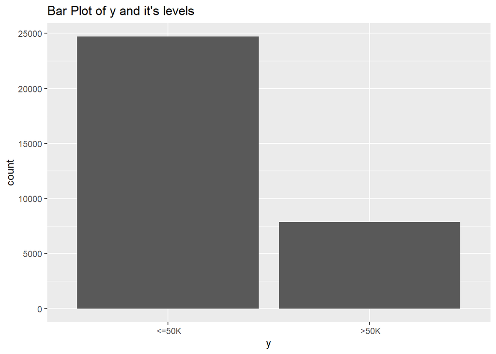

```r
# Target Variable is categorical, checking for imabalance in y using a Bar Plot, the imablance comes out to be 76 and 24% hence the majority classifier model will have an accuracy of 76%.

ggplot(data = census,
       mapping = aes(x = y)) +
  geom_bar() +
  labs(title = "Bar Plot of y and it's levels")
```

```r
census %>% select(y) %>% table()
```

```
## y
##  <=50K   >50K
##  24720   7841
```

```r
census %>% select(y) %>% table() %>% prop.table() %>% round(2) * 100
```

```
## y
##  <=50K   >50K
##     76     24
```

## 2.2 Data Visualization of numeric variables

This code chunk generates histograms and boxplots for six numeric variables (age, fnlwgt, education.num, capital.gain, capital.loss, and hours.per.week) in the census dataset, showing their distributions and central tendencies. It also computes deciles for each variable to analyze their distribution further. Additionally, it calculates the correlation matrix and displays correlations between these variables, helping to identify any significant relationships.

Results: Age is distributed a bit right-skewed with most customer’s in the range of 25 and 50 years old. Most readings for fnlwgt are distributed in between 100,000 and 250,000. Number of Eductaion years for customers mostly vary from 9 to 12 years of education. Capital gain has a value of 0 for 90% of the time and some outliers that go to 99,999 showing that most customer’s had no gain in capital. Loss in capital is similarly distributed with 90% of values as 0 with a few outliers that go to 4356 max. hours.per.week has a particular normal distribution with a mean of 40.44 which is the typical average working hours per week in the USA. The correlation matrix shows that there is not much correlation between these numeric predictors with a max correlation of around 0.15 between education.num and hours.per.week.

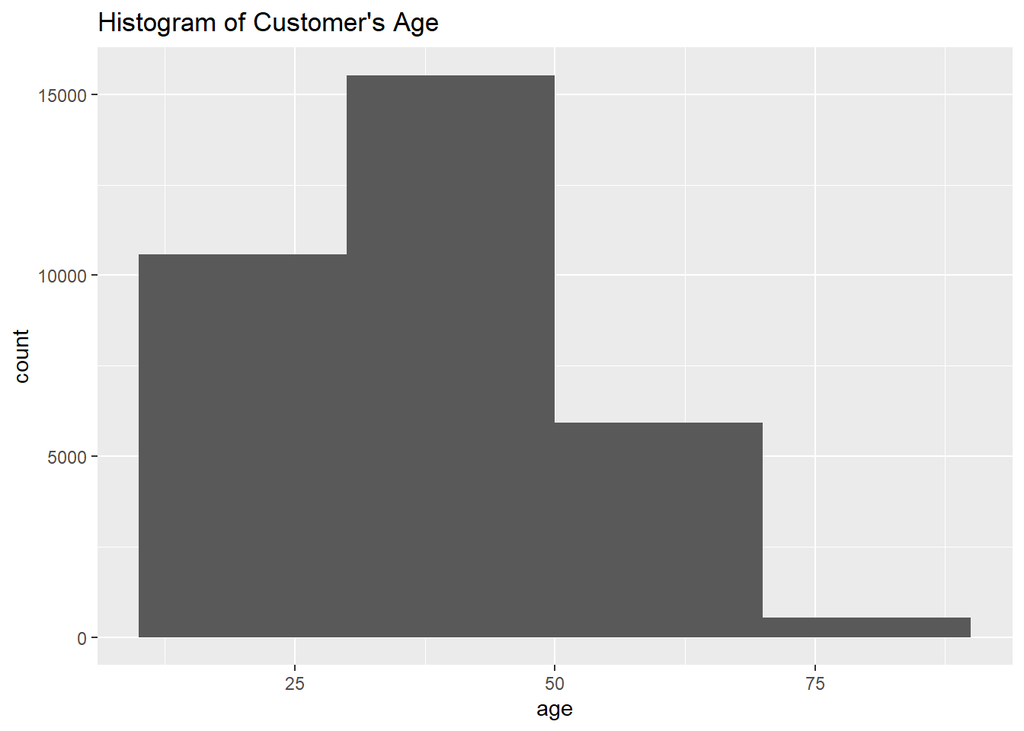

```r
# histogram of age

census %>% ggplot() +
  geom_histogram(aes(x=age),binwidth = 20) +
  ggtitle("Histogram of Customer's Age")
```

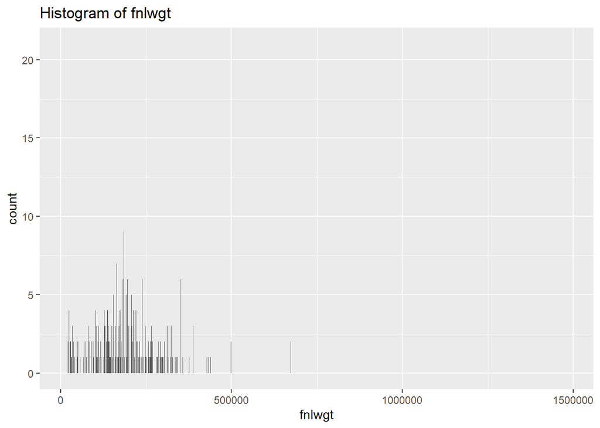

```r
# histogram of fnlwgt

census %>% ggplot() +
  geom_histogram(aes(x=fnlwgt),binwidth = 10) +
  ggtitle("Histogram of fnlwgt")
```

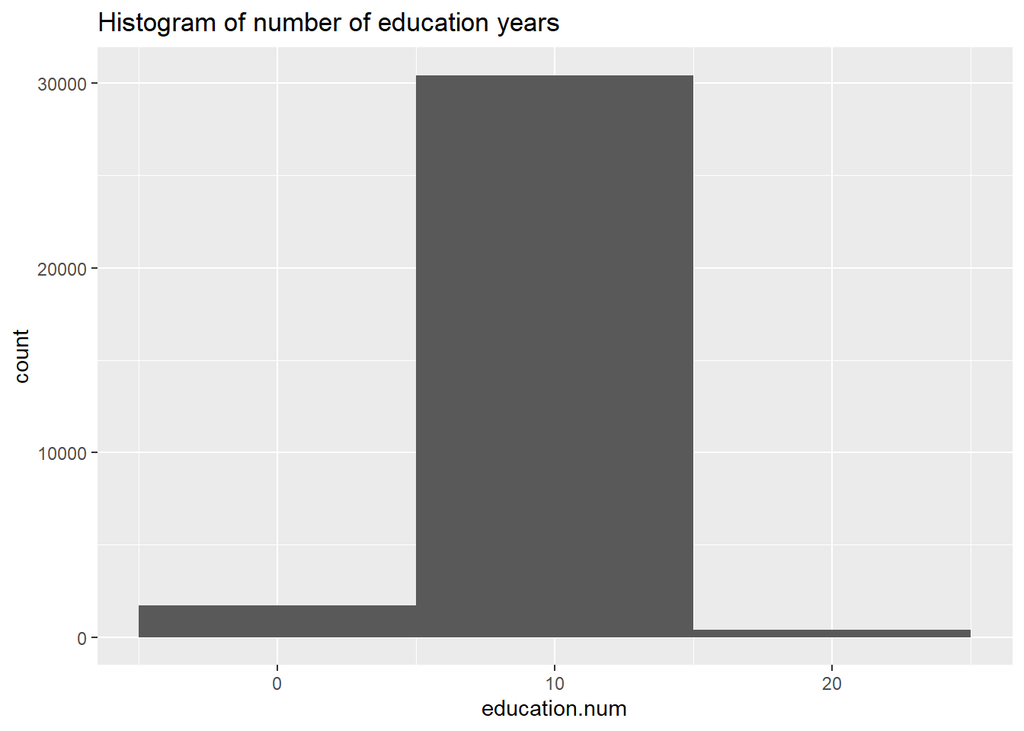

```r
# histogram of education.num

census %>% ggplot() +
  geom_histogram(aes(x=education.num),binwidth = 10) +
  ggtitle("Histogram of number of education years")
```

[figure not shown]

```r
# histogram of capital.gain

census %>% ggplot() +
  geom_histogram(aes(x=capital.gain),binwidth = 10) +
  ggtitle("Histogram of Capital Gain")
```

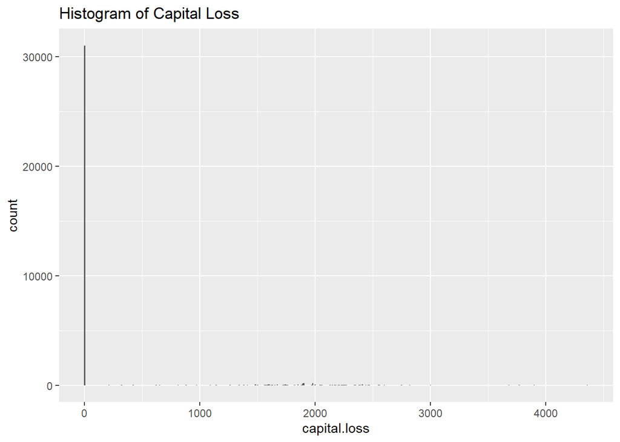

```r
# histogram of capital.loss

census %>% ggplot() +
  geom_histogram(aes(x=capital.loss),binwidth = 10) +
  ggtitle("Histogram of Capital Loss")
```

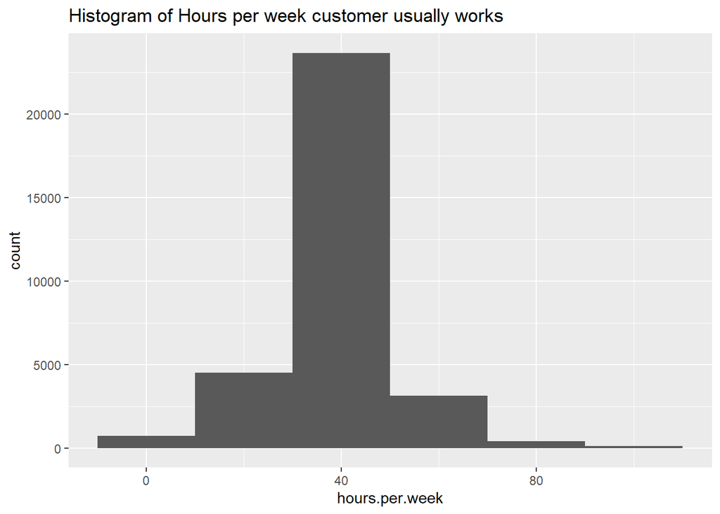

```r
# histogram of hours.per.week

census %>% ggplot() +
  geom_histogram(aes(x=hours.per.week),binwidth = 20) +
  ggtitle("Histogram of Hours per week customer usually works")
```

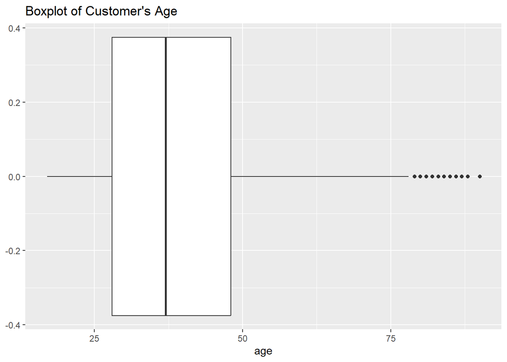

```r
# boxplot of age

census %>% ggplot() +
  geom_boxplot(aes(x=age)) +
  ggtitle("Boxplot of Customer's Age")
```

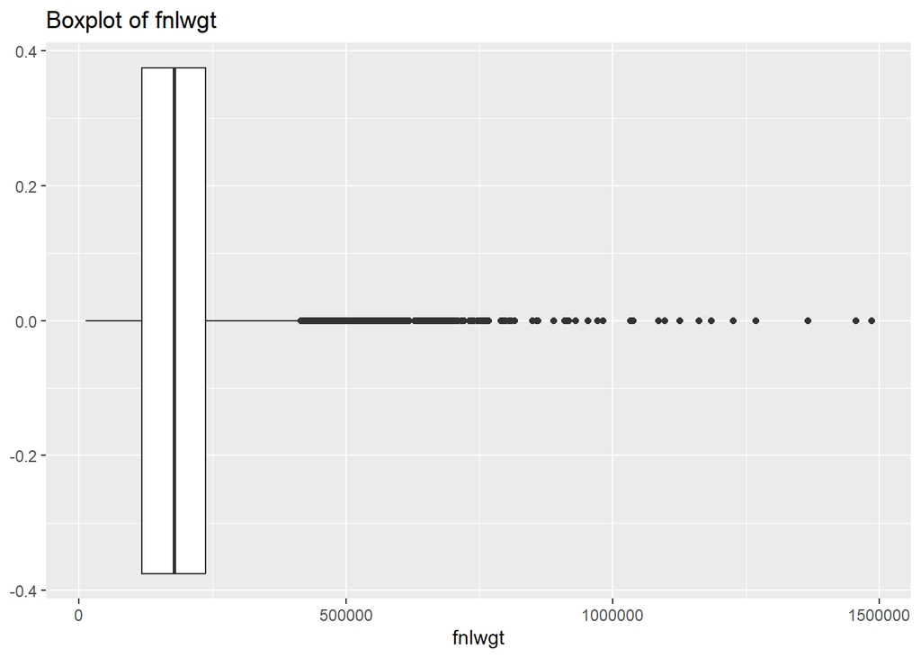

```r
# boxplot of fnlwgt

census %>% ggplot() +
  geom_boxplot(aes(x=fnlwgt)) +
  ggtitle("Boxplot of fnlwgt")
```

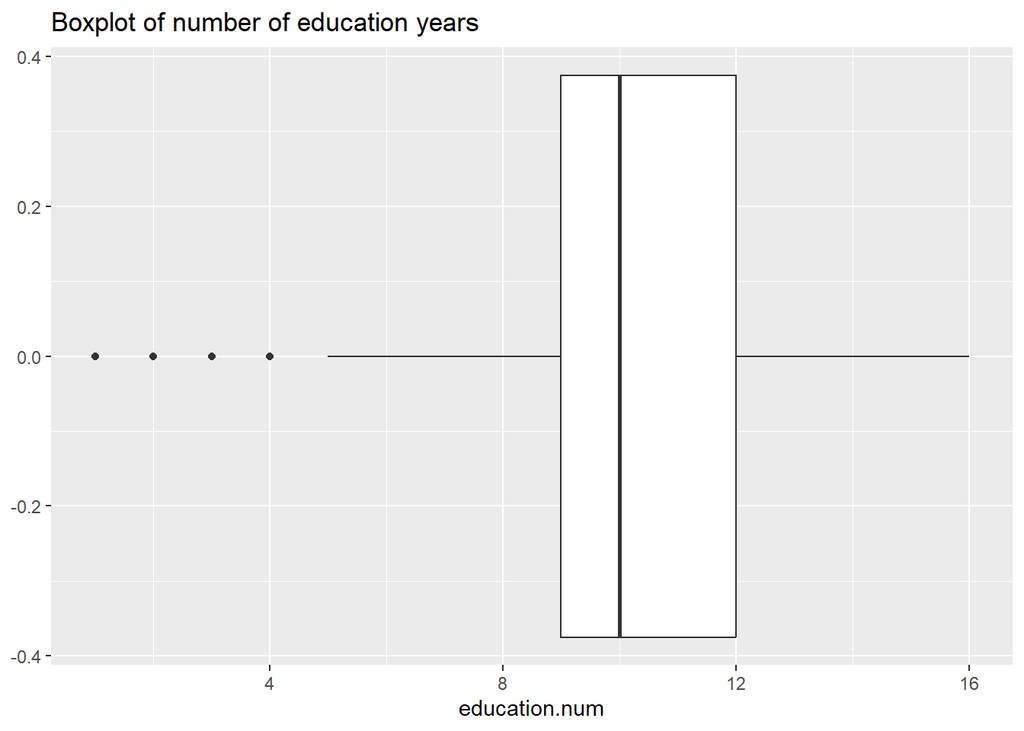

```r
# boxplot of education.num

census %>% ggplot() +
  geom_boxplot(aes(x=education.num)) +
  ggtitle("Boxplot of number of education years")
```

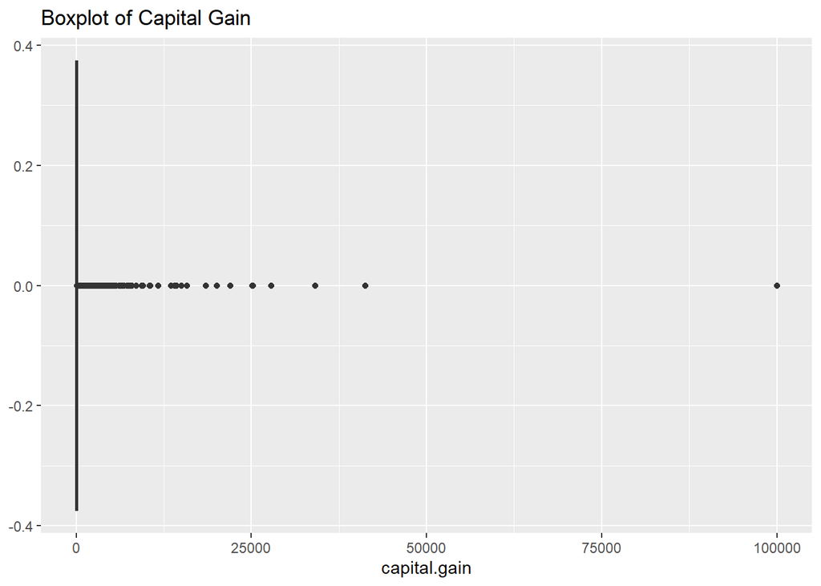

```r
# boxplot of capital.gain

census %>% ggplot() +
  geom_boxplot(aes(x=capital.gain)) +
  ggtitle("Boxplot of Capital Gain")
```

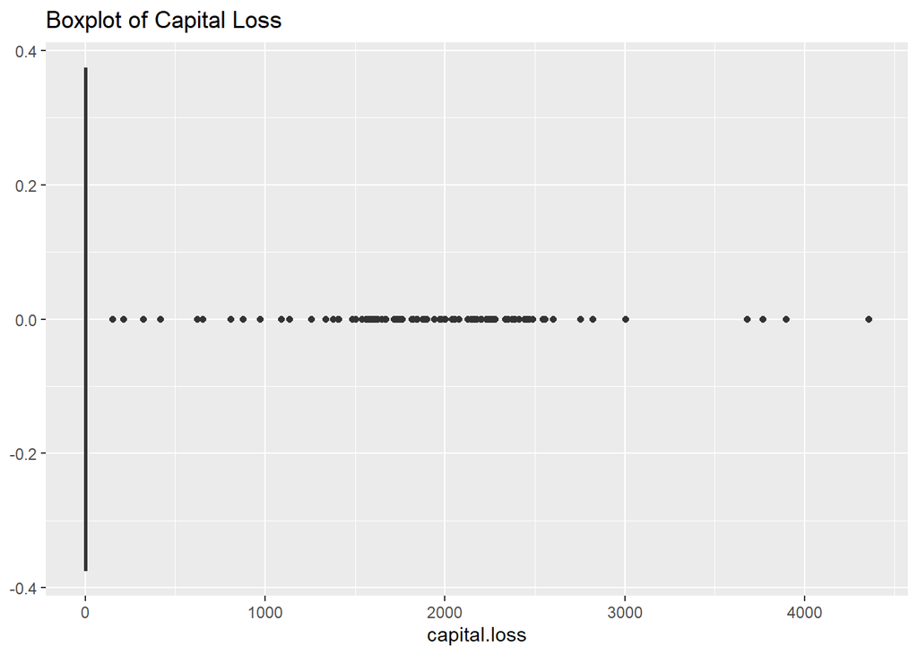

```r
# boxplot of capital.loss

census %>% ggplot() +
  geom_boxplot(aes(x=capital.loss)) +
  ggtitle("Boxplot of Capital Loss")
```

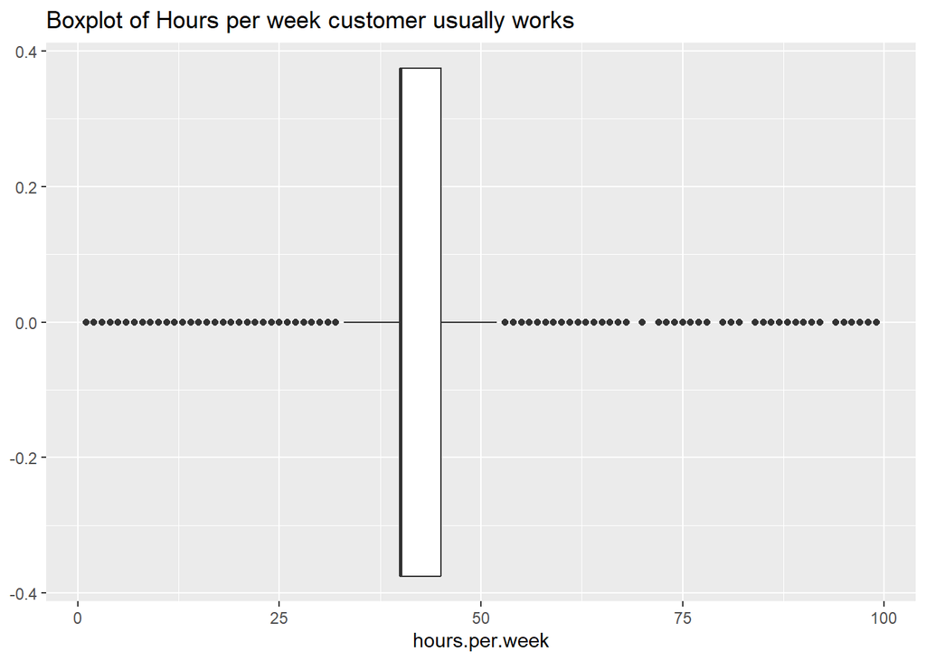

```r
# boxplot of hours.per.week

census %>% ggplot() +
  geom_boxplot(aes(x=hours.per.week)) +
  ggtitle("Boxplot of Hours per week customer usually works")
```

```r
# deciles of all six numeric variables

census %>% pull(age) %>% quantile(., seq(from = 0, to = 1, by = 0.10))
```

```
##   0%  10%  20%  30%  40%  50%  60%  70%  80%  90% 100%
##   17   22   26   30   33   37   41   45   50   58   90
```

```r
census %>% pull(fnlwgt) %>% quantile(., seq(from = 0, to = 1, by = 0.10))
```

```
##      0%     10%     20%     30%     40%     50%     60%     70%     80%     90%
##   12285   65716  106648  130856  158662  178356  196338  219632  259873  329054
##    100%
## 1484705
```

```r
census %>% pull(education.num) %>% quantile(., seq(from = 0, to = 1, by = 0.10))
```

```
##   0%  10%  20%  30%  40%  50%  60%  70%  80%  90% 100%
##    1    7    9    9    9   10   10   11   13   13   16
```

```r
census %>% pull(capital.gain) %>% quantile(., seq(from = 0, to = 1, by = 0.10))
```

```
##    0%   10%   20%   30%   40%   50%   60%   70%   80%   90%  100%
##     0     0     0     0     0     0     0     0     0     0 99999
```

```r
census %>% pull(capital.loss) %>% quantile(., seq(from = 0, to = 1, by = 0.10))
```

```
##   0%  10%  20%  30%  40%  50%  60%  70%  80%  90% 100%
##    0    0    0    0    0    0    0    0    0    0 4356
```

```r
census %>% pull(hours.per.week) %>% quantile(., seq(from = 0, to = 1, by = 0.10))
```

```
##   0%  10%  20%  30%  40%  50%  60%  70%  80%  90% 100%
##    1   24   35   40   40   40   40   40   48   55   99
```

```r
# Using cor and pairs.panels to compute correlation matrix and display correlations of the listed numeric six variables

census %>% select(age, fnlwgt, education.num, capital.gain, capital.loss, hours.per.week) %>% cor()
```

```
##                        age        fnlwgt education.num  capital.gain
## age             1.00000000 -0.0766458679    0.03652719  0.0776744982
## fnlwgt         -0.07664587  1.0000000000   -0.04319463  0.0004318858
## education.num   0.03652719 -0.0431946327    1.00000000  0.1226301147
## capital.gain    0.07767450  0.0004318858    0.12263011  1.0000000000
## capital.loss    0.05777454 -0.0102517117    0.07992296 -0.0316150630
## hours.per.week  0.06875571 -0.0187684906    0.14812273  0.0784086154
##                capital.loss hours.per.week
## age              0.05777454     0.06875571
## fnlwgt          -0.01025171    -0.01876849
## education.num    0.07992296     0.14812273
## capital.gain    -0.03161506     0.07840862
## capital.loss     1.00000000     0.05425636
## hours.per.week   0.05425636     1.00000000
```

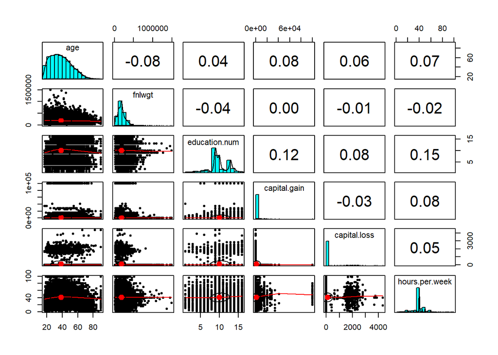

```r
census %>% select(age, fnlwgt, education.num, capital.gain, capital.loss, hours.per.week) %>% pairs.panels()
```

## 2.3 Data Exploration of factor variables

This code chunk explores the factor variables in the census dataset, including y, workclass, education, marital.status, occupation, relationship, race, sex, and native.country. It calculates the count and percentage of each factor level and displays them in tables. Then, it creates bar plots for each factor variable to visualize their distributions. The bar plots help understand the distribution and frequency of each category within the factor variables.

Results: Analysis shows a class imbalance for the target variable ‘y’ with an income of <=50k for 76% of the data and an income of >50k for the other 24% of the dataset. Boxplot highlights that most customers (about 70% of them) have a ‘Private’ workclass. For education levels, most customers are high school graduates followed by having some college experience which is followed by having a Bachelors degree. For marital status most customers are married-civ-spouse while the second majority is of clients that were never married.Occupation Type is mostly divided among the 15 levels with no class being too prominent than others. In the relationship column around 41% of customers had Husband entered in it. The race of customers in the dataset was predominantly white with 85% of the customers, while around two third of the customers in the dataset were male and about 90% of the dataset were native of United States.

```r
# Showing the count value and percentage value of each factor and it's levels

census %>% select(y) %>% table()
```

```
## y
##  <=50K   >50K
##  24720   7841
```

```r
census %>% select(y) %>% table() %>% prop.table() %>% round(2) * 100
```

```
## y
##  <=50K   >50K
##     76     24
```

```r
census %>% select(workclass) %>% table()
```

```
## workclass
##                 ?       Federal-gov         Local-gov      Never-worked
##              1836               960              2093                 7
##           Private      Self-emp-inc  Self-emp-not-inc         State-gov
##             22696              1116              2541              1298
##       Without-pay
##                14
```

```r
census %>% select(workclass) %>% table() %>% prop.table() %>% round(2) * 100
```

```
## workclass
##                 ?       Federal-gov         Local-gov      Never-worked
##                 6                 3                 6                 0
##           Private      Self-emp-inc  Self-emp-not-inc         State-gov
##                70                 3                 8                 4
##       Without-pay
##                 0
```

```r
census %>% select(education) %>% table()
```

```
## education
##          10th          11th          12th       1st-4th       5th-6th
##           933          1175           433           168           333
##       7th-8th           9th    Assoc-acdm     Assoc-voc     Bachelors
##           646           514          1067          1382          5355
##     Doctorate       HS-grad       Masters     Preschool   Prof-school
##           413         10501          1723            51           576
##  Some-college
##          7291
```

```r
census %>% select(education) %>% table() %>% prop.table() %>% round(2) * 100
```

```
## education
##          10th          11th          12th       1st-4th       5th-6th
##             3             4             1             1             1
##       7th-8th           9th    Assoc-acdm     Assoc-voc     Bachelors
##             2             2             3             4            16
##     Doctorate       HS-grad       Masters     Preschool   Prof-school
##             1            32             5             0             2
##  Some-college
##            22
```

```r
census %>% select(marital.status) %>% table()
```

```
## marital.status
##               Divorced      Married-AF-spouse     Married-civ-spouse
##                   4443                     23                  14976
##  Married-spouse-absent          Never-married              Separated
##                    418                  10683                   1025
##                Widowed
##                    993
```

```r
census %>% select(marital.status) %>% table() %>% prop.table() %>% round(2) * 100
```

```
## marital.status
##               Divorced      Married-AF-spouse     Married-civ-spouse
##                     14                      0                     46
##  Married-spouse-absent          Never-married              Separated
##                      1                     33                      3
##                Widowed
##                      3
```

```r
census %>% select(occupation) %>% table()
```

```
## occupation
##                  ?       Adm-clerical       Armed-Forces       Craft-repair
##               1843               3770                  9               4099
##    Exec-managerial    Farming-fishing  Handlers-cleaners  Machine-op-inspct
##               4066                994               1370               2002
##      Other-service    Priv-house-serv     Prof-specialty    Protective-serv
##               3295                149               4140                649
##              Sales       Tech-support   Transport-moving
##               3650                928               1597
```

```r
census %>% select(occupation) %>% table() %>% prop.table() %>% round(2) * 100
```

```
## occupation
##                  ?       Adm-clerical       Armed-Forces       Craft-repair
##                  6                 12                  0                 13
##    Exec-managerial    Farming-fishing  Handlers-cleaners  Machine-op-inspct
##                 12                  3                  4                  6
##      Other-service    Priv-house-serv     Prof-specialty    Protective-serv
##                 10                  0                 13                  2
##              Sales       Tech-support   Transport-moving
##                 11                  3                  5
```

```r
census %>% select(relationship) %>% table()
```

```
## relationship
##         Husband   Not-in-family  Other-relative       Own-child       Unmarried
##           13193            8305             981            5068            3446
##            Wife
##            1568
```

```r
census %>% select(relationship) %>% table() %>% prop.table() %>% round(2) * 100
```

```
## relationship
##         Husband   Not-in-family  Other-relative       Own-child       Unmarried
##              41              26               3              16              11
##            Wife
##               5
```

```r
census %>% select(race) %>% table()
```

```
## race
##  Amer-Indian-Eskimo  Asian-Pac-Islander               Black               Other
##                 311                1039                3124                 271
##               White
##               27816
```

```r
census %>% select(race) %>% table() %>% prop.table() %>% round(2) * 100
```

```
## race
##  Amer-Indian-Eskimo  Asian-Pac-Islander               Black               Other
##                   1                   3                  10                   1
##               White
##                  85
```

```r
census %>% select(sex) %>% table()
```

```
## sex
##  Female    Male
##   10771   21790
```

```r
census %>% select(sex) %>% table() %>% prop.table() %>% round(2) * 100
```

```
## sex
##  Female    Male
##      33      67
```

```r
census %>% select(native.country) %>% table()
```

```
## native.country
##                           ?                    Cambodia
##                         583                          19
##                      Canada                       China
##                         121                          75
##                    Columbia                        Cuba
##                          59                          95
##          Dominican-Republic                     Ecuador
##                          70                          28
##                 El-Salvador                     England
##                         106                          90
##                      France                     Germany
##                          29                         137
##                      Greece                   Guatemala
##                          29                          64
##                       Haiti          Holand-Netherlands
##                          44                           1
##                    Honduras                        Hong
##                          13                          20
##                     Hungary                       India
##                          13                         100
##                        Iran                     Ireland
##                          43                          24
##                       Italy                     Jamaica
##                          73                          81
##                       Japan                        Laos
##                          62                          18
##                      Mexico                   Nicaragua
##                         643                          34
##  Outlying-US(Guam-USVI-etc)                        Peru
##                          14                          31
##                 Philippines                      Poland
##                         198                          60
##                    Portugal                 Puerto-Rico
##                          37                         114
##                    Scotland                       South
##                          12                          80
##                      Taiwan                    Thailand
##                          51                          18
##             Trinadad&Tobago               United-States
##                          19                       29170
##                     Vietnam                  Yugoslavia
##                          67                          16
```

```r
census %>% select(native.country) %>% table() %>% prop.table() %>% round(2) * 100
```

```
## native.country
##                           ?                    Cambodia
##                           2                           0
##                      Canada                       China
##                           0                           0
##                    Columbia                        Cuba
##                           0                           0
##          Dominican-Republic                     Ecuador
##                           0                           0
##                 El-Salvador                     England
##                           0                           0
##                      France                     Germany
##                           0                           0
##                      Greece                   Guatemala
##                           0                           0
##                       Haiti          Holand-Netherlands
##                           0                           0
##                    Honduras                        Hong
##                           0                           0
##                     Hungary                       India
##                           0                           0
##                        Iran                     Ireland
##                           0                           0
##                       Italy                     Jamaica
##                           0                           0
##                       Japan                        Laos
##                           0                           0
##                      Mexico                   Nicaragua
##                           2                           0
##  Outlying-US(Guam-USVI-etc)                        Peru
##                           0                           0
##                 Philippines                      Poland
##                           1                           0
##                    Portugal                 Puerto-Rico
##                           0                           0
##                    Scotland                       South
##                           0                           0
##                      Taiwan                    Thailand
##                           0                           0
##             Trinadad&Tobago               United-States
##                           0                          90
##                     Vietnam                  Yugoslavia
##                           0                           0
```

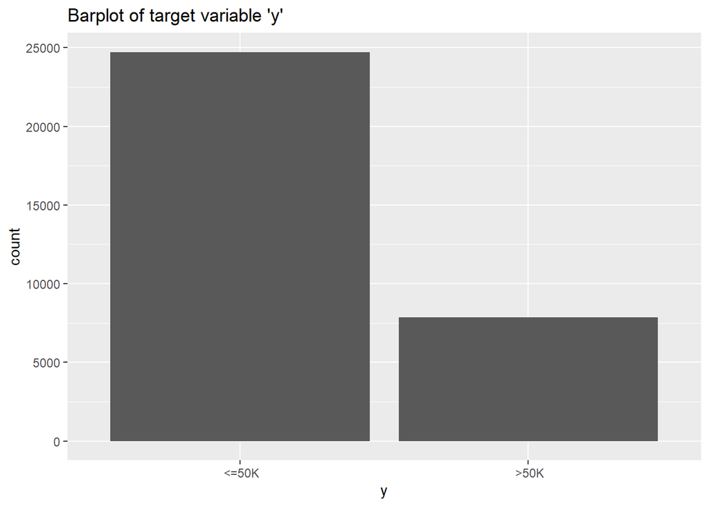

```r
# Bar plots of each of the factor variables

census %>% ggplot() +
  geom_bar(aes(x=y),position="dodge") +
  ggtitle("Barplot of target variable 'y'")
```

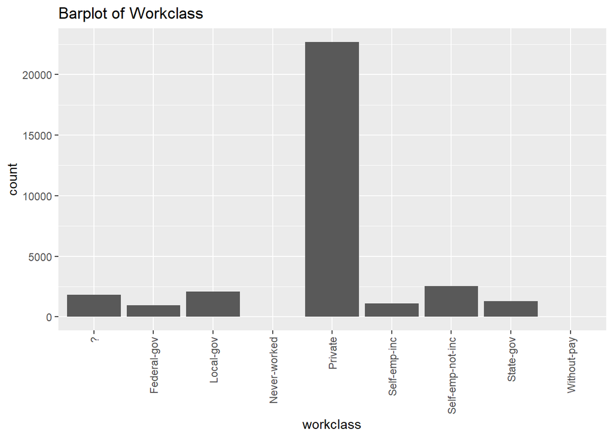

```r
census %>% ggplot() +
  geom_bar(aes(x=workclass),position="dodge") +
  theme(axis.text.x = element_text(angle = 90, vjust = 0.5, hjust=1),
        axis.text.y = element_text(angle = 0)) +
  ggtitle("Barplot of Workclass")
```

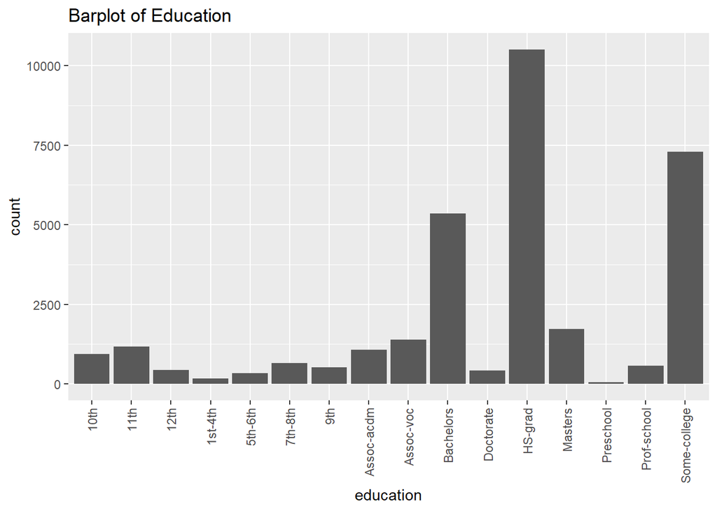

```r
census %>% ggplot() +
  geom_bar(aes(x=education),position="dodge") +
  theme(axis.text.x = element_text(angle = 90, vjust = 0.5, hjust=1),
        axis.text.y = element_text(angle = 0)) +
  ggtitle("Barplot of Education")
```

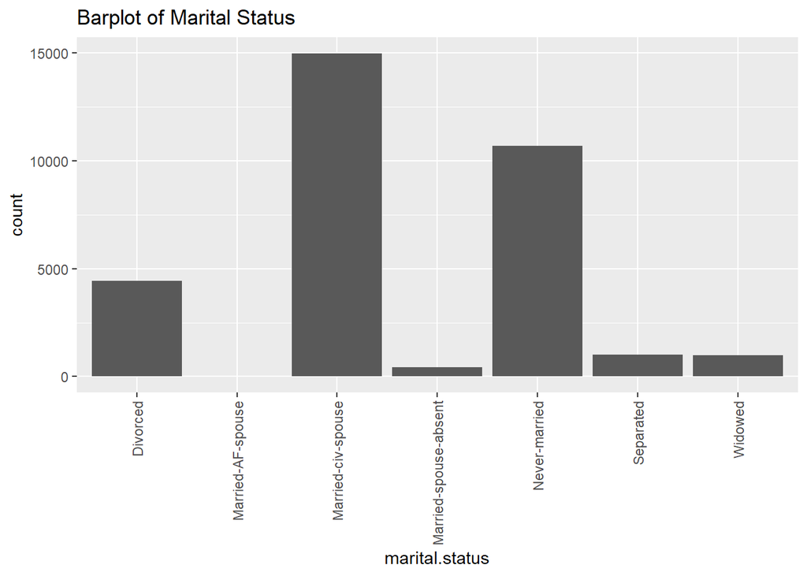

```r
census %>% ggplot() +
  geom_bar(aes(x=marital.status),position="dodge") +
  theme(axis.text.x = element_text(angle = 90, vjust = 0.5, hjust=1),
        axis.text.y = element_text(angle = 0)) +
  ggtitle("Barplot of Marital Status")
```

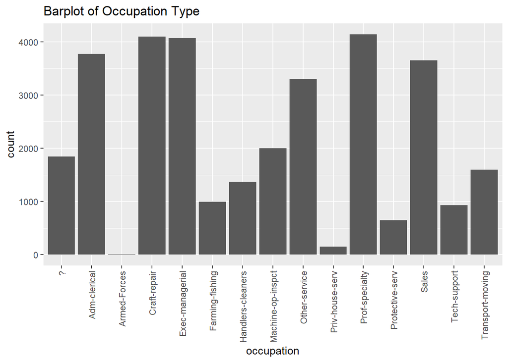

```r
census %>% ggplot() +
  geom_bar(aes(x=occupation),position="dodge") +
  theme(axis.text.x = element_text(angle = 90, vjust = 0.5, hjust=1),
        axis.text.y = element_text(angle = 0)) +
  ggtitle("Barplot of Occupation Type")
```

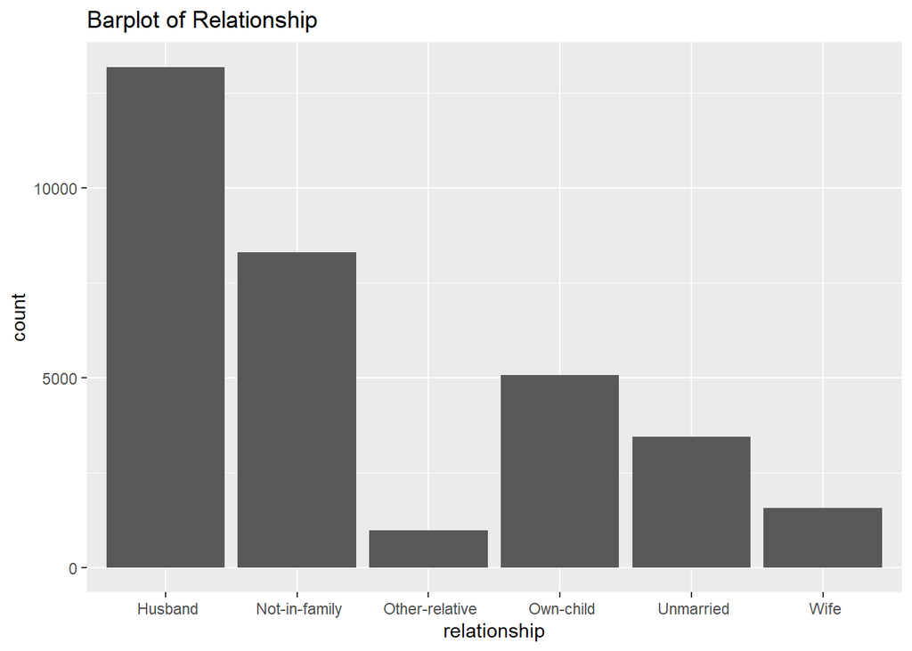

```r
census %>% ggplot() +
  geom_bar(aes(x=relationship),position="dodge") +
  ggtitle("Barplot of Relationship")
```

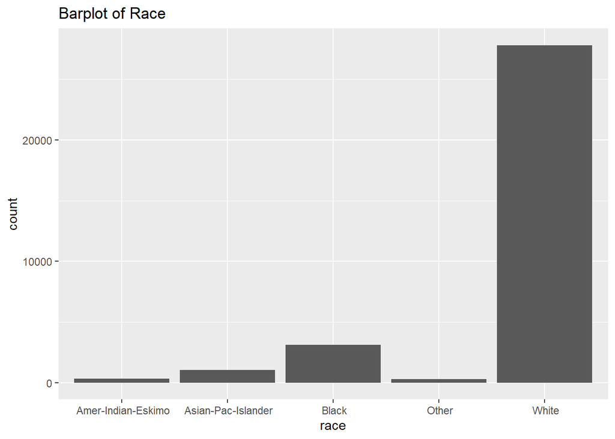

```r
census %>% ggplot() +
  geom_bar(aes(x=race),position="dodge") +
  ggtitle("Barplot of Race")
```

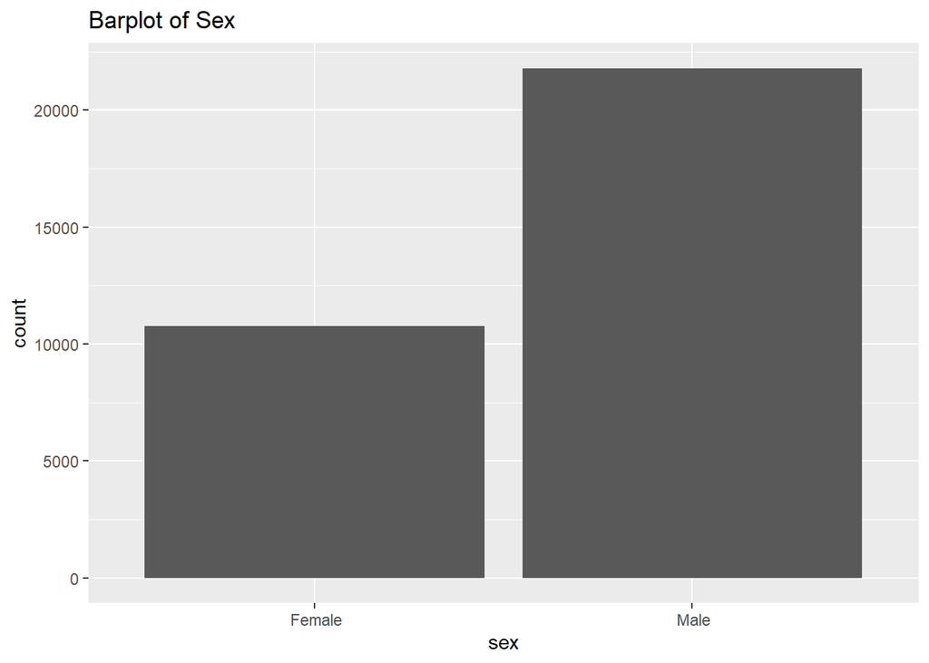

```r
census %>% ggplot() +
  geom_bar(aes(x=sex),position="dodge") +
  ggtitle("Barplot of Sex")
```

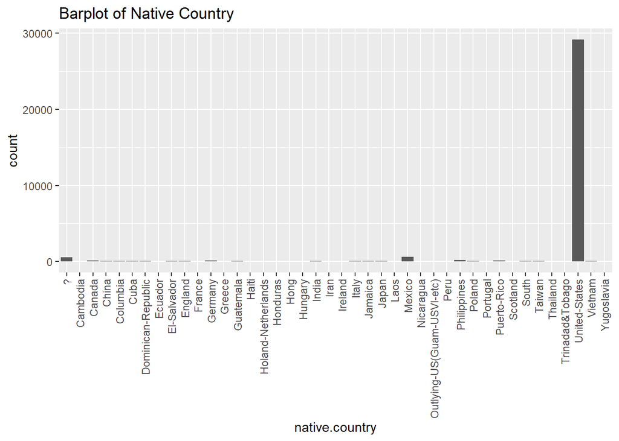

```r
census %>% ggplot() +
  geom_bar(aes(x=native.country),position="dodge") +
  theme(axis.text.x = element_text(angle = 90, vjust = 0.5, hjust=1),
        axis.text.y = element_text(angle = 0)) +
  ggtitle("Barplot of Native Country")
```